# QTL mapping using functional PCA for function-valued traits

This vignette illustrates the use of the funqtl package for QTL mapping with function-valued traits using functional principal component analysis and multi-trait mapping.

## Data

We will consider the analysis of a simulated data set, `simspal`. There are 162 recombinant inbred lines typed at a total of 234 markers on 5 chromosomes.

We first load the funqtl package (which will also load R/qtl and other packages) and the data.

```r
library(funqtl)
data(simspal)
```

Here’s a quick summary of the data.

```r
summary(simspal)
```

```
##     RI strains via selfing
##
##     No. individuals:    162
##
##     No. phenotypes:     241
##     Percent phenotyped: 100
##
##     No. chromosomes:    5
##         Autosomes:      1 2 3 4 5
##
##     Total markers:      234
##     No. markers:        26 42 64 35 67
##     Percent genotyped:  98.6
##     Genotypes (%):      AA:49.8  BB:50.2
```

The following plots the genetic marker map and the function-valued trait for five of the RIL.

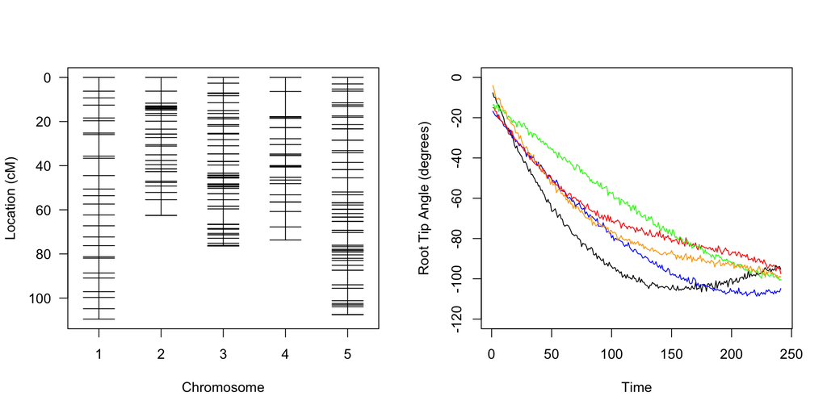

```r
par(mfrow=c(1,2))
plotMap(simspal, main="")
plot(1:241, simspal$pheno[160,], type="l", xlab="Time",
      ylim=c(-120,0), ylab="Root Tip Angle (degrees)")
ind <- c(19, 20, 132, 72)
color <- c("blue", "red", "green", "orange")
for(i in seq(along=ind))
  lines(1:241, simspal$pheno[ind[i],], col=color[i])
```

There are 162 individuals. The angle of the root tim is measured for 241 time points, which are measured every 2 minutes for eight hours.

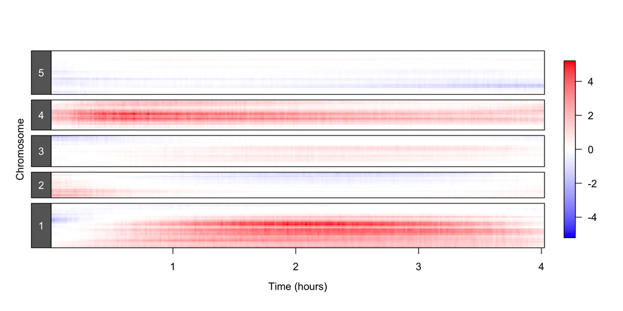

```r
out <- scanone(simspal, pheno.col=1:241, method="hk")
eff <- geteffects(simspal, pheno.cols=1:241)
nam <- phenames(simspal)
y <- as.numeric(substr(nam, 2, nchar(nam)))/60
plotlod(out, eff, y,  gap=15, horizontal = T)
```

This Figure shows the image of signed lod scores for each time points. The x-axis represent time points and y-axis represent chromosome, lod score represented as tone of the color. Red indicate positive effects and blue color indicate negative effects.

Here, we’ve got lod score for all 241 time points. Our idea is to reduce the dimension of 241 to fewer number.

1. Get estimation of smooth function for each 162 individual to control measurment error.
   - We need to decide how many base functions (b-spline) to be used estimating the smooth function.
   - This step can be done using `cvfold()` function.
2. Do functional PCA to these 162 individuals. Here we reduce the infinite dimensional function-valued data to small number of principal components.
3. Do qtl mapping with these principal components. Combine the information using our proposed test statistics. (HKLOD, SL and ML)

```r
set.seed(1)
cvout <- cvfold(simspal, basisset = 15:60, fold = 10, random = F)
```

The 1st step is to decide how many basis functions to use estimating our function-valued trait. If we use too much basis it will fit the measurement error as well which is not meaningful. If we use too few basis the estimation may not enough to represent the truth.

We’ve developed `cvfold` function to decide the number of basis functions. `basisset` option describe the number of basis sets to be tested. `fold` indicate how many folders to be used in cross validation. In this code, we divide our time points with equily spaced 10 sets. We used 9 folder to evaluate the functional. And calculated sum of squared errors for the left one folder.

The Figure shows the sum of error losses (y- axis) for each number of basis from 15 to 60.

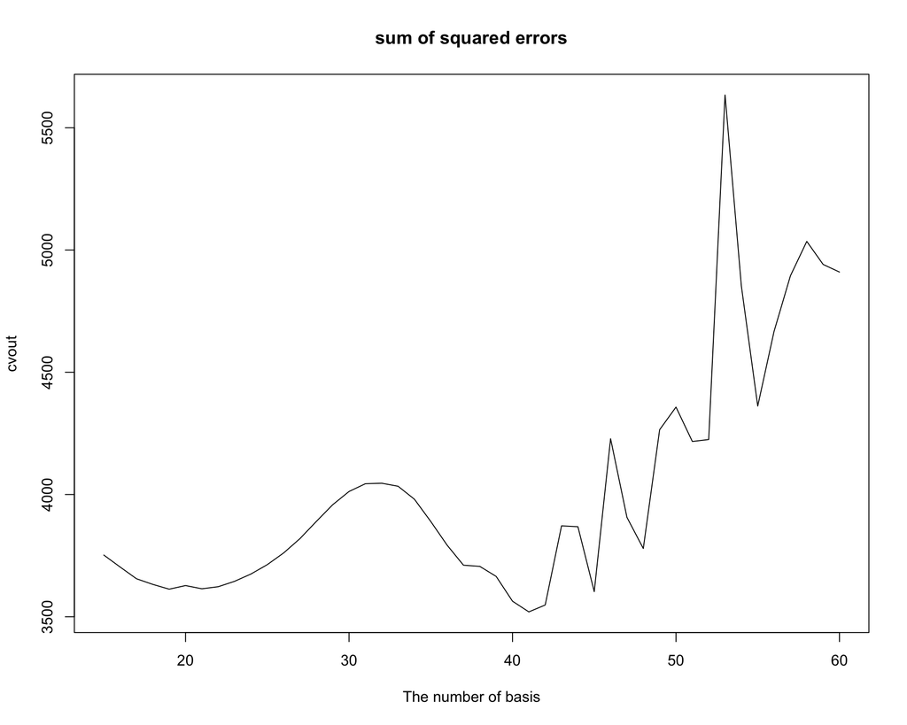

```r
plot(15:60, cvout, xlab = "The number of basis",
     main = "sum of squared errors", type = "l")
```

```r
which(cvout == min(cvout))
```

```
## 41
## 27
```

The minimum error loss calculated when we used 41 basis. So we decided to use 41 B-spline basis functions.

## HKLOD, SL and ML scores

```r
cfpc <- calcfunpca(simspal, criteria=0.99, nbasis = 41)
Y <- cfpc$Y
eigfc <- cfpc$eigf

dim(Y)
```

```
## [1] 162   4
```

```r
Y[1:10,]
```

```
##              PC1      PC2        PC3       PC4
##  [1,]  -903.7400 221.8631 -107.06066 -120.1815
##  [2,] -1229.2545 171.1248  -95.29325 -140.7525
##  [3,] -1246.8675 227.2852 -158.71505 -133.5347
##  [4,] -1327.3137 179.6724 -114.09467 -124.0108
##  [5,] -1081.8138 153.8482 -145.80452 -146.7473
##  [6,] -1170.0532 187.0432 -112.30235 -132.0673
##  [7,]  -983.8873 262.9096 -128.67069 -115.6567
##  [8,] -1155.9584 220.7031 -155.52029 -125.4240
##  [9,] -1001.6113 286.1447 -138.34373 -120.9453
## [10,] -1024.5831 267.8272 -123.80506 -171.3865
```

Now, we can used `calcfunpca` function to get small number of principal components.

41 B-spline basis functions are used. the number of 4 PCs are selected they explain more than 99 percent of data variation.

To convert those PCs back to original data information, we can use ‘eigfc’ object.

```r
# PC for 1st individual
Y[1,]
```

```
##       PC1       PC2       PC3       PC4
## -903.7400  221.8631 -107.0607 -120.1815
```

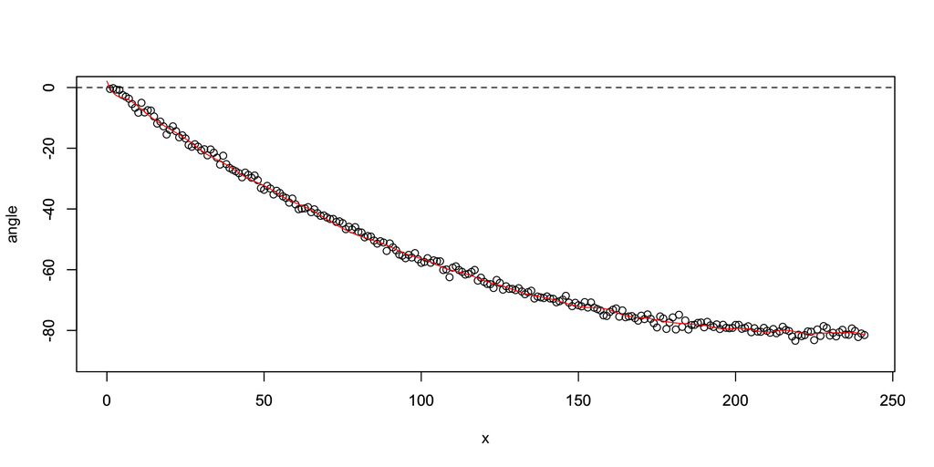

```
## [1] "done"
```

```r
# plot the 1st individual ( raw data)
plot(1:241,simspal$pheno[1,], xlim=c(0,241), ylim=c(-90,0), ylab="angle", xlab="x")
par(new=T)
# plot the recovered data using PC
plot( -903.74*cfpc$eigf[1] + 222 *cfpc$eigf[2] -107*cfpc$eigf[3] -120 * cfpc$eigf[4], xlim=c(0,241), ylim=c(-90,0), col = "red", ylab="", xlab="")
```

The example shows how we can recover the 1st individual using PCs.

```r
outhk <- scanoneM(simspal, Y = Y, method="hk")
outsl <- scanoneM(simspal, Y = Y, method="sl")
outml <- scanoneM(simspal, Y = Y, method="ml")
```

We proposed HKLOD, SL and ML scores, this statistic can be obtained using `scanoneM` function.

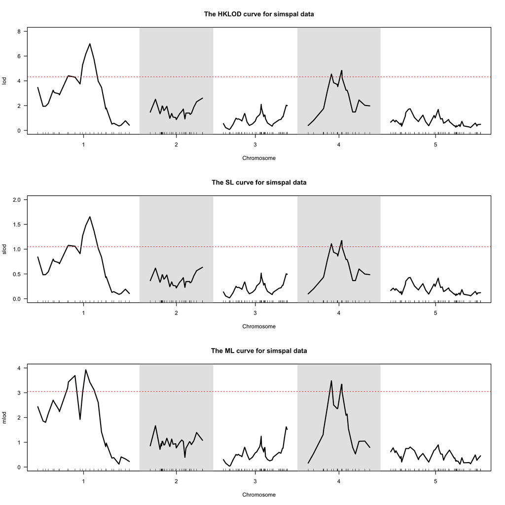

```r
par(mfrow=c(3,1))
plot(outhk, ylim=c(0,8), main="The HKLOD curve for simspal data",
     bandcol="gray90")
abline(h=4.32, col="red", lty=3)
plot(outsl, ylim=c(0,2), main="The SL curve for simspal data",
     bandcol="gray90")
abline(h=1.05, col="red", lty=3)
plot(outml, ylim=c(0,4), main="The ML curve for simspal data",
     bandcol="gray90")
abline(h=3.05, col="red", lty=3)
```

```r
# permutation threshold
# permouthk <- scanoneF(simspal, Y=Y, method = "hk", n.perm=1000)
# permoutf <- scanoneF(simspal, Y=Y, method = "f", n.perm=1000)
# permoutsl <- scanoneF(simspal, Y=Y, method = "sl", n.perm=1000)
# permoutml <- scanoneF(simspal, Y=Y, method = "ml", n.perm=1000)
# summary(permouthk) # display 5, 10 % threshold
# summary(permoutf) # display 5, 10 % threshold
# summary(permoutsl) # display 5, 10 % threshold
# summary(permoutml) # display 5, 10 % threshold
```

The results are in Figure above. Horizontal lines indicate the 5% genome-wide significance thresholds, derived by a permutation test. We didn’t run the code (for permutation test) above since it takes a long time (about one hour maybe) .

## Getting multiple QTL

```r
qtlhk <- stepwiseqtlM(simspal, Y = Y, max.qtl=6 , method = "hk", penalties = c(4.44, 10, 18), additive.only = T )
```

```
##  -Initial scan
## ** new best ** (pLOD increased by 2.555)
##     no.qtl =  1   pLOD = 2.554964   formula: y ~ Q1
##  -Step 1
##  ---Scanning for additive qtl
##         plod = 3.208052
##  ---Refining positions
##     no.qtl =  2   pLOD = 3.208052   formula: y ~ Q1 + Q2
## ** new best ** (pLOD increased by 0.6531)
##  -Step 2
##  ---Scanning for additive qtl
##         plod = 1.468638
##  ---Refining positions
##     no.qtl =  3   pLOD = 1.468638   formula: y ~ Q1 + Q2 + Q3
##  -Step 3
##  ---Scanning for additive qtl
##         plod = -0.4206258
##  ---Refining positions
##     no.qtl =  4   pLOD = -0.4206258   formula: y ~ Q1 + Q2 + Q3 + Q4
##  -Step 4
##  ---Scanning for additive qtl
##         plod = -2.455176
##  ---Refining positions
##     no.qtl =  5   pLOD = -2.455176   formula: y ~ Q1 + Q2 + Q3 + Q4 + Q5
##  -Step 5
##  ---Scanning for additive qtl
##         plod = -3.744527
##  ---Refining positions
##  ---  Moved a bit
##     no.qtl =  6   pLOD = -3.38537   formula: y ~ Q1 + Q2 + Q3 + Q4 + Q5 + Q6
##  -Starting backward deletion
##  ---Dropping Q3
##     no.qtl =  5   pLOD = -1.918663   formula: y ~ Q1 + Q2 + Q3 + Q4 + Q5
##  ---Refining positions
##  ---Dropping Q3
##     no.qtl =  4   pLOD = -0.4675776   formula: y ~ Q1 + Q2 + Q3 + Q4
##  ---Refining positions
##  ---  Moved a bit
##  ---Dropping Q3
##     no.qtl =  3   pLOD = 0.901747   formula: y ~ Q1 + Q2 + Q3
##  ---Refining positions
##  ---  Moved a bit
##  ---Dropping Q3
##     no.qtl =  2   pLOD = 3.208052   formula: y ~ Q1 + Q2
##  ---Refining positions
##  ---Dropping Q2
##     no.qtl =  1   pLOD = 2.554964   formula: y ~ Q1
##  ---Refining positions
```

```r
qtlml <- stepwiseqtlM(simspal, Y = Y, max.qtl=8 , method = "ml", penalties = c(2.05, 8, 8), additive.only = T )
```

```
##  -Initial scan
## ** new best ** (pLOD increased by 1.8785)
##     no.qtl =  1   pLOD = 1.878513   formula: y ~ Q1
##  -Step 1
##  ---Scanning for additive qtl
##         plod = 3.145657
##  ---Refining positions
##     no.qtl =  2   pLOD = 3.145657   formula: y ~ Q1 + Q2
## ** new best ** (pLOD increased by 1.2671)
##  -Step 2
##  ---Scanning for additive qtl
##         plod = 3.081701
##  ---Refining positions
##     no.qtl =  3   pLOD = 3.081701   formula: y ~ Q1 + Q2 + Q3
##  -Step 3
##  ---Scanning for additive qtl
##         plod = 2.798956
##  ---Refining positions
##     no.qtl =  4   pLOD = 2.798956   formula: y ~ Q1 + Q2 + Q3 + Q4
##  -Step 4
##  ---Scanning for additive qtl
##         plod = 0.9685021
##  ---Refining positions
##  ---  Moved a bit
##     no.qtl =  5   pLOD = 1.611057   formula: y ~ Q1 + Q2 + Q3 + Q4 + Q5
##  -Step 5
##  ---Scanning for additive qtl
##         plod = -0.1220567
##  ---Refining positions
##  ---  Moved a bit
##     no.qtl =  6   pLOD = 1.064444   formula: y ~ Q1 + Q2 + Q3 + Q4 + Q5 + Q6
##  -Step 6
##  ---Scanning for additive qtl
##         plod = -0.977073
##  ---Refining positions
##  ---  Moved a bit
##     no.qtl =  7   pLOD = 0.1129066   formula: y ~ Q1 + Q2 + Q3 + Q4 + Q5 + Q6 + Q7
##  -Step 7
##  ---Scanning for additive qtl
##         plod = -1.896001
```

[output cut: 12 more lines]

```
##     no.qtl =  5   pLOD = 2.635989   formula: y ~ Q1 + Q2 + Q3 + Q4 + Q5
##  ---Refining positions
##  ---Dropping Q5
##     no.qtl =  4   pLOD = 3.067093   formula: y ~ Q1 + Q2 + Q3 + Q4
##  ---Refining positions
##  ---Dropping Q4
##     no.qtl =  3   pLOD = 2.47086   formula: y ~ Q1 + Q2 + Q3
##  ---Refining positions
##  ---  Moved a bit
##  ---Dropping Q3
##     no.qtl =  2   pLOD = 3.145657   formula: y ~ Q1 + Q2
##  ---Refining positions
##  ---Dropping Q2
##     no.qtl =  1   pLOD = 1.878513   formula: y ~ Q1
##  ---Refining positions
```

```r
qtlsl <- stepwiseqtlM(simspal, Y = Y, max.qtl=8 , method = "sl", penalties = c(1.07, 8, 8), additive.only = T )
```

```
##  -Initial scan
## ** new best ** (pLOD increased by 0.5813)
##     no.qtl =  1   pLOD = 0.5812575   formula: y ~ Q1
##  -Step 1
##  ---Scanning for additive qtl
##         plod = 0.8016048
##  ---Refining positions
##     no.qtl =  2   pLOD = 0.8016048   formula: y ~ Q1 + Q2
## ** new best ** (pLOD increased by 0.2203)
##  -Step 2
##  ---Scanning for additive qtl
##         plod = 0.3915321
##  ---Refining positions
##     no.qtl =  3   pLOD = 0.3915321   formula: y ~ Q1 + Q2 + Q3
##  -Step 3
##  ---Scanning for additive qtl
##         plod = -0.07309657
##  ---Refining positions
##     no.qtl =  4   pLOD = -0.07309657   formula: y ~ Q1 + Q2 + Q3 + Q4
##  -Step 4
##  ---Scanning for additive qtl
##         plod = -0.5704659
##  ---Refining positions
##     no.qtl =  5   pLOD = -0.5704659   formula: y ~ Q1 + Q2 + Q3 + Q4 + Q5
##  -Step 5
##  ---Scanning for additive qtl
##         plod = -0.8452813
##  ---Refining positions
##  ---  Moved a bit
##     no.qtl =  6   pLOD = -0.7610157   formula: y ~ Q1 + Q2 + Q3 + Q4 + Q5 + Q6
##  -Step 6
##  ---Scanning for additive qtl
##         plod = -1.163812
##  ---Refining positions
##     no.qtl =  7   pLOD = -1.163812   formula: y ~ Q1 + Q2 + Q3 + Q4 + Q5 + Q6 + Q7
##  -Step 7
##  ---Scanning for additive qtl
##         plod = -1.707696
##  ---Refining positions
##  ---  Moved a bit
```

[output cut: 10 more lines]

```
##     no.qtl =  5   pLOD = -0.3889937   formula: y ~ Q1 + Q2 + Q3 + Q4 + Q5
##  ---Refining positions
##  ---Dropping Q3
##     no.qtl =  4   pLOD = -0.02225778   formula: y ~ Q1 + Q2 + Q3 + Q4
##  ---Refining positions
##  ---Dropping Q3
##     no.qtl =  3   pLOD = 0.2371079   formula: y ~ Q1 + Q2 + Q3
##  ---Refining positions
##  ---  Moved a bit
##  ---Dropping Q3
##     no.qtl =  2   pLOD = 0.8016048   formula: y ~ Q1 + Q2
##  ---Refining positions
##  ---Dropping Q2
##     no.qtl =  1   pLOD = 0.5812575   formula: y ~ Q1
##  ---Refining positions
```

```r
qtlhk
```

```
##   QTL object containing genotype probabilities.
##
##      name chr    pos n.gen
## Q1 1@62.3   1 62.324     2
## Q2 4@40.3   4 40.290     2
##
##   Formula: y ~ Q1 + Q2
##
##   pLOD:  3.208
```

```r
qtlsl
```

```
##   QTL object containing genotype probabilities.
##
##      name chr    pos n.gen
## Q1 1@62.3   1 62.324     2
## Q2 4@40.3   4 40.290     2
##
##   Formula: y ~ Q1 + Q2
##
##   pLOD:  0.802
```

```r
qtlml
```

```
##   QTL object containing genotype probabilities.
##
##      name chr    pos n.gen
## Q1 1@57.4   1 57.406     2
## Q2 4@39.9   4 39.943     2
##
##   Formula: y ~ Q1 + Q2
##
##   pLOD:  3.146
```

`stepwiseqtlM` function returns qtl object by using stepwise QTL selection.

```r
par(mfrow=c(3,1))

    rqtlhk <- refineqtlM(cross = simspal, Y = Y, qtl = qtlhk, method = "hk" )
```

```
## pos: 62.3236 40.28959
## Iteration 1
##  Q1 pos: 62.3236 -> 62.3236
##     LOD increase:  0
##  Q2 pos: 40.28959 -> 40.28959
##     LOD increase:  0
## all pos: 62.3236 40.28959 -> 62.3236 40.28959
## LOD increase at this iteration:  0
## overall pos: 62.3236 40.28959 -> 62.3236 40.28959
## LOD increase overall:  0
```

```r
    rqtlsl <- refineqtlM(cross = simspal, Y = Y, qtl = qtlsl, method = "sl" )
```

```
## pos: 62.3236 40.28959
## Iteration 1
##  Q1 pos: 62.3236 -> 62.3236
##     LOD increase:  0
##  Q2 pos: 40.28959 -> 40.28959
##     LOD increase:  0
## all pos: 62.3236 40.28959 -> 62.3236 40.28959
## LOD increase at this iteration:  0
## overall pos: 62.3236 40.28959 -> 62.3236 40.28959
## LOD increase overall:  0
```

```r
    rqtlml <- refineqtlM(cross = simspal, Y = Y, qtl = qtlml, method = "ml" )
```

```
## pos: 57.40582 39.94289
## Iteration 1
##  Q1 pos: 57.40582 -> 57.40582
##     LOD increase:  0
##  Q2 pos: 39.94289 -> 39.94289
##     LOD increase:  0
## all pos: 57.40582 39.94289 -> 57.40582 39.94289
## LOD increase at this iteration:  0
## overall pos: 57.40582 39.94289 -> 57.40582 39.94289
## LOD increase overall:  0
```

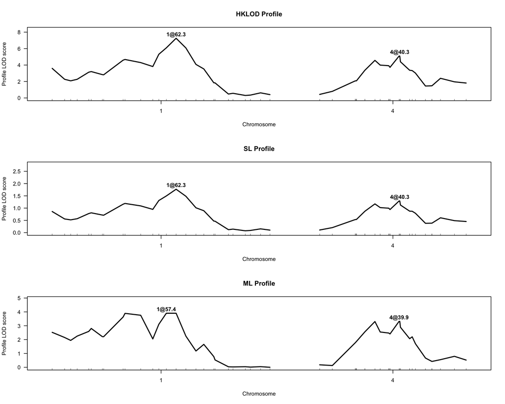

```r
plotLodProfile(rqtlhk, ylab = "Profile LOD score", main = "HKLOD Profile")
plotLodProfile(rqtlsl, ylab = "Profile LOD score", main = "SL Profile")
plotLodProfile(rqtlml, ylab = "Profile LOD score", main = "ML Profile")
```

You can also make profile curves by using `refineqtlM` and `plotLodProfile` function. Here are HKLOD, SL and ML profile curves. All the method found 2-QTL model.

## Effect plot

```r
## getting Principal componetes.
Z <- calcfunpca(simspal, n.max=8, criteria = .99, nbasis = 30)

### This can be manualy done as follows ( this step needed to get eigen functions)

Y = t(simspal$pheno)
m = 241 # time dimension

## creating 30 b-spline basis using 4 knots
splinebasis.y <- create.bspline.basis(c(0, m), 30, 4)
time <- 0:(m - 1) + 0.5

## do smoothing
mat <- eval.basis(time, splinebasis.y)
coef.y <- solve(crossprod(mat), crossprod(mat, Y))

## get smoothed Y phenotype. now Y is n number of functionals
yfd = fd(coef.y, splinebasis.y, list("time", "indv", "value"))

## Do functional PCA
y.pcalist3 = pca.fd(yfd, 20)

## The proportion variance explained from eigen functions
y.pcalist3$varprop
```

```
##  [1] 8.285929e-01 1.044871e-01 5.499397e-02 1.093040e-02 6.952561e-05
##  [6] 6.674249e-05 5.992196e-05 5.752277e-05 5.615101e-05 5.375070e-05
## [11] 4.813015e-05 4.615560e-05 4.420127e-05 4.194585e-05 4.092614e-05
## [16] 3.804884e-05 3.667173e-05 3.500552e-05 3.273298e-05 3.050656e-05
```

```r
## first 4 eigen values explain more than 99 percent of data variation.
sum(y.pcalist3$varprop[1:4])
```

```
## [1] 0.9990044
```

```r
sum(y.pcalist3$varprop[1:3])
```

```
## [1] 0.988074
```

```r
y.pcalist3 = pca.fd(yfd, 4)
eigfc3 <- y.pcalist3$harmonics
mat3 <- eval.fd(time, eigfc3)
nY3 <- t(solve(crossprod(mat3), crossprod(mat3, Y)))

temp <- simspal
temp$pheno[,1] <- Z$Y[,1]
temp$pheno[,2] <- Z$Y[,2]
temp$pheno[,3] <- Z$Y[,3]
temp$pheno[,4] <- Z$Y[,4]

hksleff <- vector("list", 4)
for(i in 1:4) {
  hksleff[[i]] <- summary(fitqtl(temp, phe=i, qtl=rqtlhk, method="hk", get.ests=TRUE, dropone=FALSE))$ests[,1]*c(1,2,2)
}

nam <- names(hksleff[[1]])
hksleff <- matrix(unlist(hksleff), byrow=TRUE, ncol=length(nam))
colnames(hksleff) <- nam
```

By using these 4 eigen functions, we can recover effect functions. `hksleff` have the coefficients for baseline, Q1 and Q2 effect functions. We can draw baseline, Q1 and Q2 effect function as follows.

```r
par(mfrow=c(1,3))
par(las=1)

baselinehk <- hksleff[1,1] * eigfc3[1]
for(j in 2:4)
    baselinehk = baselinehk + hksleff[j,1] * eigfc3[j]

time <- (0:240)/30
x = (0:240)

plot(baselinehk, xlim = c(0,250), ylim=c(-110,0), xaxt = "n", ylab="", col="red")
```

```
## [1] "done"
```

```r
axis(1, at = x[c(1,61,121,181,241)] , labels = time[c(1,61,121,181,241)])
mtext("Time (hours)", side=1, line = 2.8, cex = .7)
mtext("Tip angle (degrees)", side=2, line = 2.8, las=3, cex = .7)

q1hk <- hksleff[1,2] * eigfc3[1]
for(j in 2:4)
    q1hk = q1hk + hksleff[j,2] * eigfc3[j]

plot(q1hk, xlim = c(0,250), ylim=c(-5,9), xaxt = "n", col="red", ylab="")
```

```
## [1] "done"
```

```r
axis(1, at = x[c(1,61,121,181,241)] , labels = time[c(1,61,121,181,241)])
mtext("Time (hours)", side=1, line = 2.8, cex = .7)
mtext("QTL effect", side=2, line = 2.8, las=3, cex = .7)
abline(h = 0, lty=2)

q2hk <- hksleff[1,3] * eigfc3[1]
for(j in 2:4)
    q2hk = q2hk + hksleff[j,3] * eigfc3[j]

plot(q2hk, xlim = c(0,250), ylim=c(-5,9), xaxt = "n", col="red", ylab="")
```

```
## [1] "done"
```

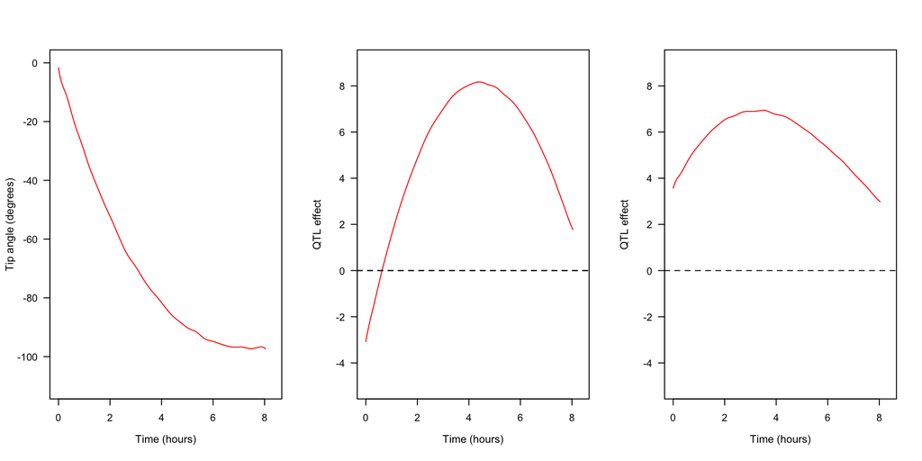

```r
axis(1, at = x[c(1,61,121,181,241)] , labels = time[c(1,61,121,181,241)])
mtext("Time (hours)", side=1, line = 2.8, cex = .7)
mtext("QTL effect", side=2, line = 2.8, las=3, cex = .7)
abline(h = 0, lty=2)
```